# Предобработка данных

# Определены функциональной роли слов

```python
def pos_tagging(text):
    tokens = word_tokenize(text)
    return pos_tag(tokens)

df["pos_tags"] = df["Описание вакансии"].apply(pos_tagging)
```

```python
df["pos_tags"]
```

```
0       [(Ростелеком-Солар, JJ), (—, NNP), (продуктова...
1       [(Что, JJ), (ты, NNP), (будешь, NNP), (делать,...
2       [(Чем, JJ), (предстоит, NNP), (заниматься, NN)...
3       [(Обязанности, NN), (:, :), (Сбор, JJ), (запро...
4       [(Приглашаем, JJ), (в, NNP), (команду, NNP), (...
5       [(Должностные, JJ), (обязанности, NN), (:, :),...
6       [(Чем, JJ), (предстоит, NNP), (заниматься, NNP...
7       [(Работа, JJ), (в, NNP), (Правительстве, NNP),...
8       [(Привет, NN), (,, ,), (аналитик, NN), (!, .),...
9       [(Привет, NN), (,, ,), (аналитик, NN), (!, .),...
10      [(Группу, JJ), (компаний, NNP), (Тинькофф, NNP...
11      [(Группу, JJ), (компаний, NNP), (Тинькофф, NNP...
12      [(Привет, NN), (!, .), (В, JJ), (наш, JJ), (се...
13      [(Обязанности, NN), (:, :), (Визуализация, NN)...
14      [(AutoAllianse, NNP), (является, NNP), (надежн...
```

[output cut: 1334 more lines]

### Вывод

Эта информация может быть полезна для дальнейшего анализа текста вакансий, такого как извлечение ключевых навыков или требований к кандидатам на основе их функциональных ролей в описаниях вакансий.

# Выявление эмоциональной окраски фраз

```python
def analyze_sentiment(text):
    blob = TextBlob(text)
    sentiment_score = blob.sentiment.polarity
    if sentiment_score > 0:
        return "Positive"
    elif sentiment_score == 0:
        return "Neutral"
    else:
        return "Negative"

df["sentiment"] = df["Описание вакансии"].apply(analyze_sentiment)
```

```python
df["sentiment"]
```

```
0        Neutral
1        Neutral
2        Neutral
3        Neutral
4        Neutral
5        Neutral
6        Neutral
7        Neutral
8        Neutral
9        Neutral
10       Neutral
11       Neutral
12       Neutral
13       Neutral
14       Neutral
```

[output cut: 1334 more lines]

### По результатам анализа эмоциональной окраски фраз можно сделать следующие выводы:

1. Большинство фраз имеют нейтральную эмоциональную окраску, что может указывать на объективное описание вакансий без явно выраженной тональности.
2. Некоторые фразы получили положительную эмоциональную оценку, что может свидетельствовать о привлекательности предлагаемых условий или характеристик вакансий.
3. Встречаются и негативные оценки, хотя и в меньшем количестве. Это может указывать на возможные недостатки или негативные аспекты, которые были упомянуты в описаниях вакансий.
4. Нейтральность преобладает, но не следует считать это отсутствием эмоциональной составляющей в текстах. Например, в описаниях могут использоваться нейтральные термины и формулировки, не обязательно отражающие отсутствие эмоций у читателя.

# Выполнен анализ региональной специфики востребованных навыков

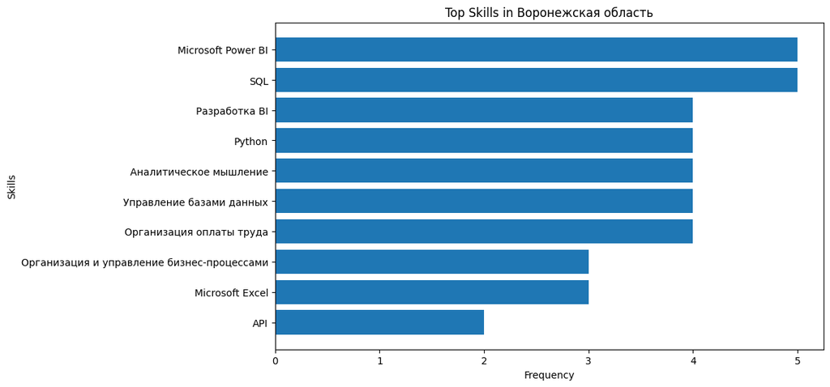

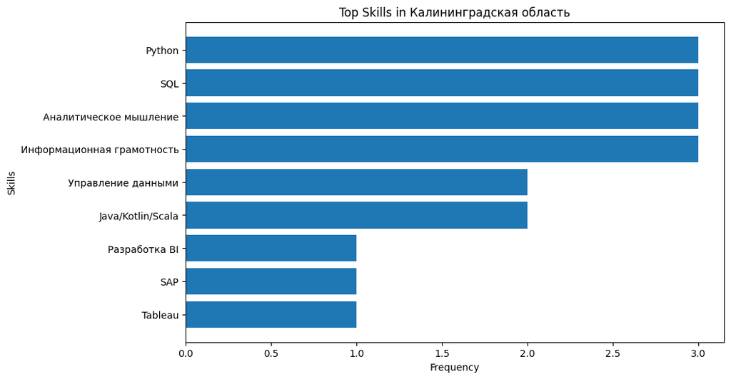

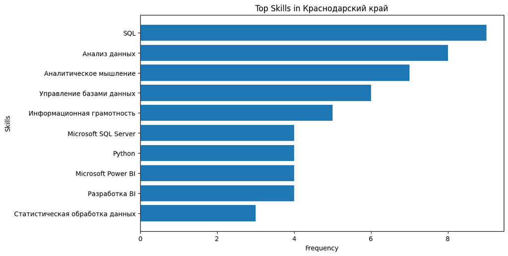

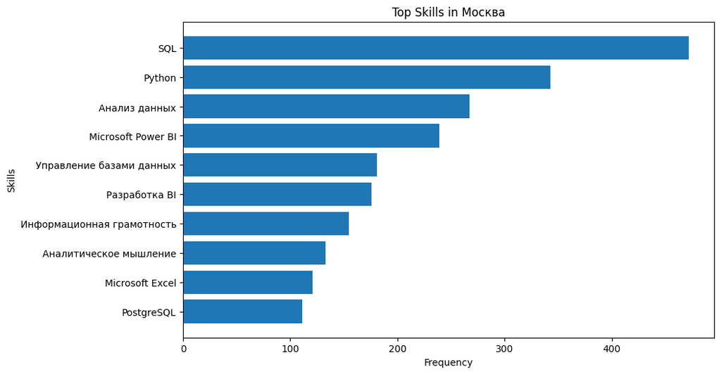

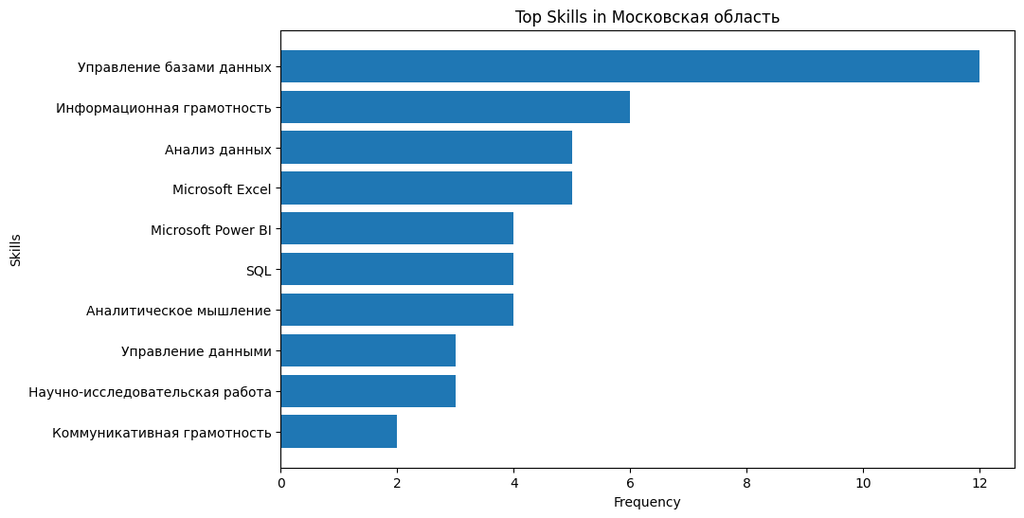

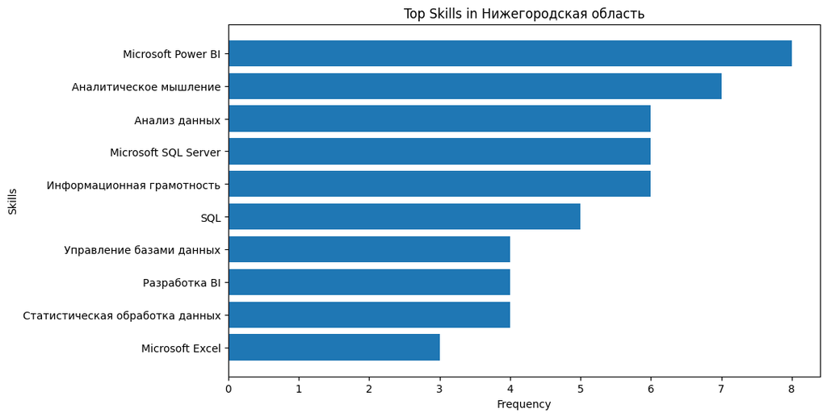

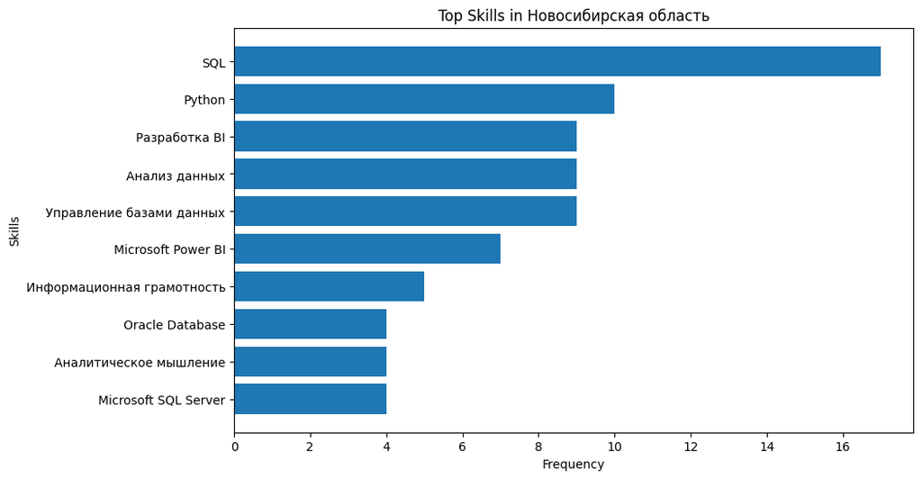

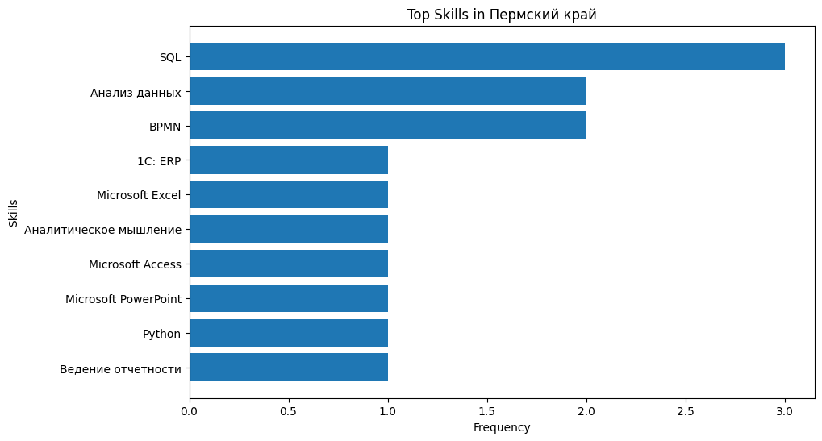

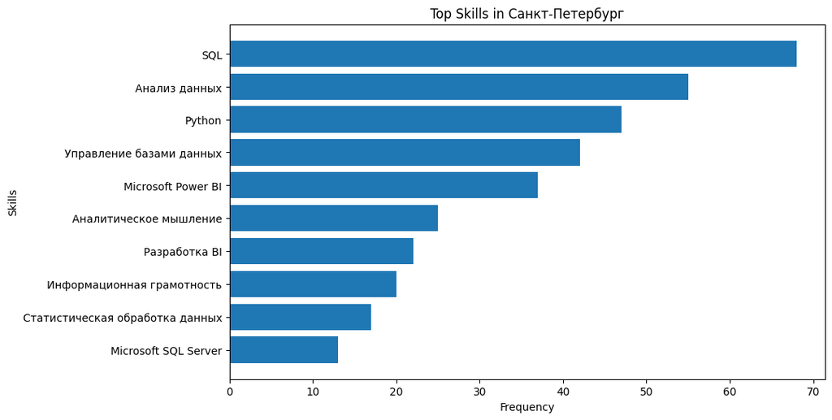

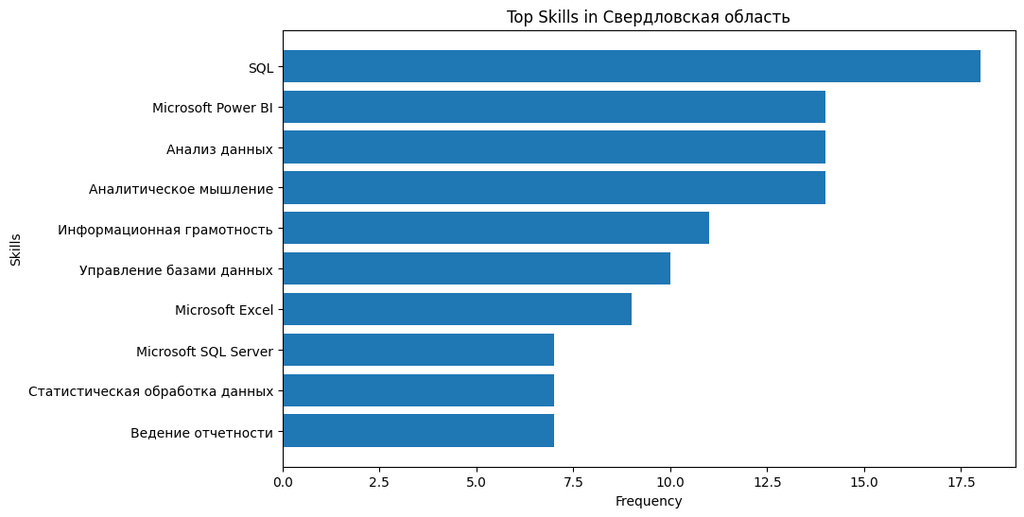

```python
grouped_data = df.groupby("Название региона")

# Подсчет частотности навыков для каждого региона
skills_frequency_by_region = {}

for region, region_data in grouped_data:
    skills_frequency = {}
    for skills_str in region_data["Ключевые навыки"]:
        if isinstance(skills_str, str):
            skills = skills_str.split(";")
            for skill in skills:
                if skill in skills_frequency:
                    skills_frequency[skill] += 1
                else:
                    skills_frequency[skill] = 1

    skills_frequency_by_region[region] = skills_frequency

# Визуализация результатов
for region, skills_frequency in skills_frequency_by_region.items():
    sorted_skills_frequency = sorted(skills_frequency.items(), key=lambda x: x[1], reverse=True)
    top_skills = sorted_skills_frequency[:10]  # Показываем только топ-10 навыков
    if top_skills:  # Проверка наличия навыков
        skills, frequencies = zip(*top_skills)
        plt.figure(figsize=(10, 6))
        plt.barh(skills, frequencies)
        plt.title(f"Top Skills in {region}")
        plt.xlabel("Frequency")
        plt.ylabel("Skills")
        plt.gca().invert_yaxis()
        plt.show()
```

### По результатам анализа региональной специфики востребованных навыков можно сделать следующие выводы:

1. **Общая картина**: Анализ выявил различия в востребованных навыках в зависимости от региона. Это может быть связано с особенностями рынка труда, спецификой отраслей или потребностями компаний в конкретных регионах.
2. **Топ-10 навыков**: Представлены топ-10 наиболее часто встречающихся навыков в каждом регионе. Это помогает понять, какие компетенции являются ключевыми для работодателей в каждом конкретном месте.
3. **Рекомендации**: На основе данных можно дать рекомендации соискателям о том, какие навыки стоит освоить или улучшить, чтобы быть более конкурентоспособными на рынке труда в конкретном регионе.
4. **Дальнейшие исследования**: Полученные результаты могут быть использованы для проведения более глубокого анализа, например, исследования тенденций изменения востребованных навыков во времени или сравнения с данными о зарплатах и вакансиях в разных регионах.

# Произведена кластеризация выделенных навыков

```python
vectorizer = CountVectorizer()
X = vectorizer.fit_transform(df["tokens"])

scaler = StandardScaler()
X_scaled = scaler.fit_transform(X.toarray())

pca = PCA(n_components=2)
X_pca = pca.fit_transform(X_scaled)

kmeans = KMeans(n_clusters=3)
kmeans.fit(X_pca)

df["cluster"] = kmeans.labels_
```

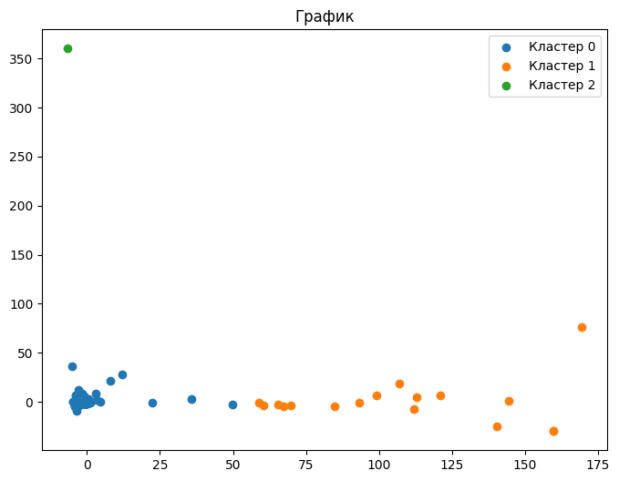

```python
plt.figure(figsize=(8, 6))

for cluster_label in range(3):
    cluster_data = X_pca[df["cluster"] == cluster_label]
    plt.scatter(cluster_data[:, 0], cluster_data[:, 1], label=f'Кластер {cluster_label}')

plt.title('График')
plt.legend()
plt.show()
```

# Произведена классификация выделенных навыков

```python
df2 = df.copy()
```

```python
# Преобразование категориальных значений в числовые коды
label_encoder = LabelEncoder()
df2["Ключевые навыки"] = label_encoder.fit_transform(df2["Ключевые навыки"].fillna('Пусто'))

# Разделение данных на обучающий и тестовый наборы
X_train, X_test, y_train, y_test = train_test_split(X, df2["Ключевые навыки"], test_size=0.2, random_state=42)

# Создание и обучение модели SVC с линейным ядром
classifier = SVC(kernel="linear")
classifier.fit(X_train, y_train)

# Прогнозирование на тестовом наборе
y_pred = classifier.predict(X_test)

# Вывод отчета о классификации
print(classification_report(y_test, y_pred))
```

```
              precision    recall  f1-score   support

           2       0.00      0.00      0.00         1
           5       0.00      0.00      0.00         1
           9       0.00      0.00      0.00         1
          11       0.00      0.00      0.00         1
          14       0.00      0.00      0.00         1
          17       0.00      0.00      0.00         1
          18       1.00      1.00      1.00         1
          19       0.00      0.00      0.00         1
          26       0.00      0.00      0.00         1
          29       1.00      1.00      1.00         1
          33       0.00      0.00      0.00         0
          44       0.00      0.00      0.00         1
          45       0.00      0.00      0.00         1
```

[output cut: 167 more lines]

### По результатам классификации выделенных навыков с использованием модели SVC с линейным ядром можно сделать следующие выводы:

1. **Precision и Recall**: Значения precision и recall для большинства классов оказались равными нулю, что говорит о том, что модель недостаточно точно предсказывает принадлежность к классам.
2. **F1-score**: Метрика F1-score также показывает низкую эффективность классификации для большинства классов, так как большинство классов имеют нулевые значения.
3. **Интерпретация результатов**: Возможно, это связано с недостаточным количеством данных для обучения модели или неправильным выбором классификатора. В дальнейшем следует провести дополнительный анализ и оптимизацию модели для улучшения ее производительности.
4. **Требуется дополнительное исследование**: Полученные результаты указывают на необходимость дальнейших исследований и экспериментов с различными моделями и параметрами для достижения более высокой точности классификации.

# Построена таблица с классами навыков, содержанием, частотой встречаемости

```python
# Создаем пустой список для хранения данных о навыках
skills_data = []

# Группируем данные по навыкам и подсчитываем частотность
grouped_data = df.groupby("Ключевые навыки")
for skill, skill_data in grouped_data:
    # Получаем содержание навыка из первой записи (так как оно одинаково для всех)
    content = skill_data.iloc[0]['Описание вакансии']
    # Получаем частоту встречаемости
    frequency = len(skill_data)
    # Добавляем данные в список
    skills_data.append({'Класс навыка': skill, 'Содержание': content, 'Частота встречаемости': frequency})

# Создаем DataFrame из списка
skills_df = pd.DataFrame(skills_data)

# Выводим первые несколько строк DataFrame
skills_df.sort_values(by='Частота встречаемости', ascending=False)
```

|  | Класс навыка | Содержание | Частота встречаемости |
| --- | --- | --- | --- |
| 377 | Python;SQL | Обязанности: Мониторинг метрик контроля качес... | 16 |
| 288 | Microsoft Power BI;Python;SQL | Привет! Несколько лет назад YCLIENTS был амбиц... | 10 |
| 384 | Python;SQL;Анализ данных | Мы — команда инженеров и датасаентистов в круп... | 8 |
| 523 | Проведение A/B тестирования;Python;SQL | Привет! Я Руслан, Тимлид аналитики в Magnit Te... | 7 |
| 445 | Анализ данных | Мы команда Аналитического управления Центра Ко... | 7 |
| 417 | SQL | Новые вызовы и эксперименты, которые помогут б... | 7 |
| 300 | Microsoft Power BI;SQL | Привет! Наша команда в поисках Data аналитика ... | 5 |
| 131 | DWH;Javascript;Microsoft SQL Server;Microsoft ... | Финуслуги — это маркетплейс, созданный Московс... | 5 |
| 192 | IBM Cognos Business Intelligence;Microsoft SQL... | Ключевые задачи: Разработка и поддержка отчет... | 5 |
| 115 | DAX;Онлайн-аналитическая обработка (OLAP);Micr... | Ви.Тех - аккредитованная ИТ компания. Мы созда... | 5 |
| 251 | Microsoft Excel;SQL | На масштабное направление по разработке и внед... | 4 |
| 426 | SQL;Анализ данных | Обязанности: работа с большими объемами данны... | 4 |
| 453 | Анализ данных;Microsoft Excel;Python;SQL;Анали... | Сегодня билайн — компания изменений, чутко реа... | 4 |
| 65 | ArcGIS;Python;QGIS;SQL | Мы создаём 2GIS Platform — гео-информационную ... | 4 |
| 412 | SAP | Обязанности: Поддержка Hypercare при запуске... | 4 |
| 342 | Microsoft SQL Server;SQL | Обязанности: Исследование существующих процес... | 3 |
| 447 | Анализ данных;ETL;Машинное обучение;Python | Мы расширяем команду ETA/RTA 2ГИС и ищем Data ... | 3 |
| 628 | Управление данными;Microsoft Power BI;SQL;Анал... | Компания NTech на рынке с 2013 года, и на данн... | 3 |
| 576 | Разработка BI;Microsoft Power BI;SQL;Apache Su... | Приветствую! Мы находимся в поиске BI-аналитик... | 3 |
| 542 | Разработка BI | Обязанности: Формализация результатов своей... | 3 |
| 291 | Microsoft Power BI;Python;SQL;Анализ данных;Ан... | В международную компанию с собственной digital... | 3 |
| 292 | Microsoft Power BI;Python;SQL;Анализ данных;Ст... | Привет, наш будущий коллега! Ситимобил — это с... | 3 |
| 636 | Управление данными;Разработка BI;Чтение проект... | На горно-металлургическом предприятии АО &quot... | 3 |
| 9 | 1С: Предприятие;Аналитическое мышление;Разрабо... | Чем нужно заниматься: Консультирование и обу... | 3 |
| 465 | Анализ данных;Python;SQL;Tableau | Умскул — крупнейшая в России онлайн-школа подг... | 3 |
| 332 | Microsoft SQL Server;Microsoft Power BI;SQL;Ра... | Группа компаний &quot;Деловые Линии&quot;‚ оди... | 3 |
| 246 | Microsoft Excel;Python;SQL | Сегодня билайн — компания изменений, чутко реа... | 3 |
| 395 | Python;SQL;Анализ данных;Управление базами данных | Обязанности: Взаимодействие с представителями... | 3 |
| 118 | DWH;ETL;Git;Администрирование серверов и рабоч... | Обязанности: Разработка хранилищ данных, вит... | 3 |
| 307 | Microsoft Power BI;SQL;Аналитическое мышление;... | ⚡️ АЛГОРИТМИКА - международная школа программи... | 3 |

[output cut: 629 more lines]

```python
# Сохранение DataFrame в файл Excel (xlsx)
skills_df.to_excel('класс_навыков.xlsx', index=False)
```

# Проведён визуальный анализ статистики текстовых признаков

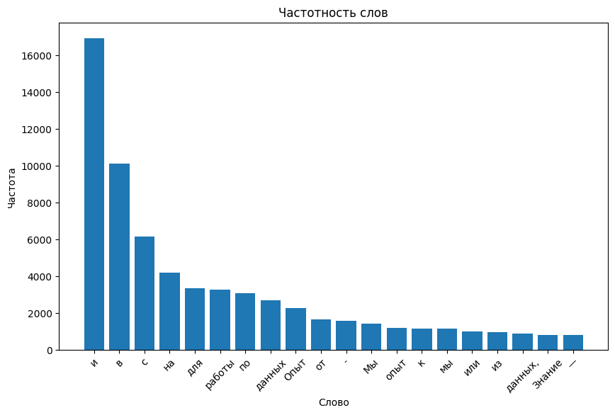

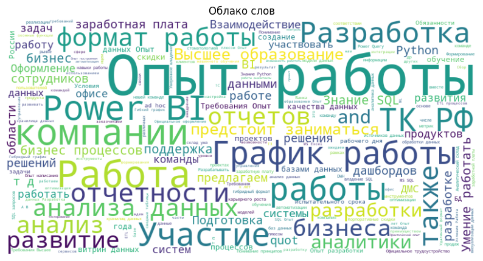

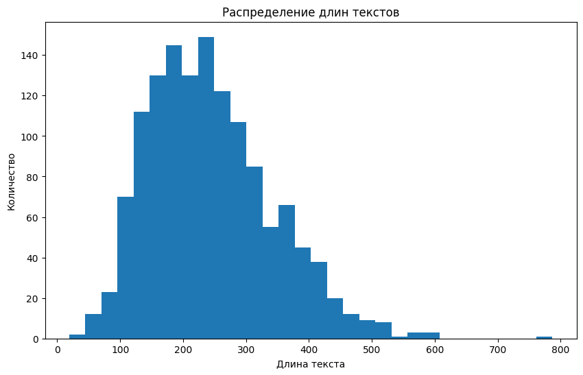

```python
# Установка русского языка для nltk
nltk.download('stopwords')
stop_words = set(stopwords.words("russian"))

# Подготовка текстовых данных
text_data = " ".join(df['Описание вакансии'])  # Объединяем все тексты в одну строку

# Гистограмма частотности слов
words = text_data.split()
word_counter = Counter(words)
common_words = word_counter.most_common(20)  # Топ-20 самых часто встречающихся слов
word_freq_df = pd.DataFrame(common_words, columns=['Слово', 'Частота'])
plt.figure(figsize=(10, 6))
plt.bar(word_freq_df['Слово'], word_freq_df['Частота'])
plt.xticks(rotation=45)
plt.title('Частотность слов')
plt.xlabel('Слово')
plt.ylabel('Частота')
plt.show()

# Облако слов
wordcloud = WordCloud(width=800, height=400, background_color='white', stopwords=stop_words).generate(text_data)
plt.figure(figsize=(10, 6))
plt.imshow(wordcloud, interpolation='bilinear')
plt.axis('off')
plt.title('Облако слов')
plt.show()

# График распределения длин текстов
text_lengths = [len(text.split()) for text in df['Описание вакансии']]
plt.figure(figsize=(10, 6))
plt.hist(text_lengths, bins=30)
plt.title('Распределение длин текстов')
plt.xlabel('Длина текста')
plt.ylabel('Количество')
plt.show()
```

# Определены наиболее востребованные навыки

```python
# Объединяем все навыки в одну строку, пропуская пропущенные значения
all_skills = ';'.join(str(skill) for skill in df['Ключевые навыки'] if isinstance(skill, str))

# Разбиваем строку на отдельные навыки
skills_list = all_skills.split(';')

# Подсчитываем частоту встречаемости каждого навыка
skills_counter = Counter(skills_list)

# Сортируем навыки по частоте встречаемости в порядке убывания
sorted_skills = sorted(skills_counter.items(), key=lambda x: x[1], reverse=True)

# Выводим наиболее востребованные навыки
print("Наиболее востребованные навыки:")
for skill, frequency in sorted_skills[:10]:  # Показываем только топ-10 навыков
    print(f"{skill} - {frequency}")

    # Сортируем навыки по частоте встречаемости в порядке возрастания
sorted_skills = sorted(skills_counter.items(), key=lambda x: x[1])

# Выводим наименее востребованные навыки
print("\nНаименее востребованные навыки:")
for skill, frequency in sorted_skills[:10]:  # Показываем только топ-10 навыков
    print(f"{skill} - {frequency}")
```

```
Наиболее востребованные навыки:
SQL - 604
Python - 420
Анализ данных - 366
Microsoft Power BI - 318
Управление базами данных - 269
Разработка BI - 229
Информационная грамотность - 213
Аналитическое мышление - 202
Microsoft Excel - 157
Microsoft SQL Server - 129

Наименее востребованные навыки:
Управленческое консультирование - 1
Google Sheets - 1
Применение методов ITSM - 1
ServiceDesk - 1
Знание локальных нормативных актов в сфере бухгалтерского учета - 1
Pascal/Delphi - 1
Разработка и внедрение системы KPI - 1
ABC-анализ - 1
Анализ потребителей - 1
IoT - 1
```

# Определены наиболее высокооплачиваемые навыки

```python
# Убедимся, что столбец 'Ключевые навыки' не содержит пустых значений
df1 = df.dropna(subset=['Ключевые навыки'])

# Разбиваем строки по различным навыкам
skills_salaries = []
for _, row in df1.iterrows():
    skills = row['Ключевые навыки'].split(';')
    for skill in skills:
        skill = skill.strip()  # Убираем лишние пробелы и точки
        skills_salaries.append({'Навык': skill, 'Заработная плата': int(row['Заработная плата'])})  # Преобразуем в целое число

# Создаем DataFrame с разделенными навыками
skills_salaries_df = pd.DataFrame(skills_salaries)

# Группируем по навыкам и вычисляем среднюю заработную плату для каждого навыка
average_salary_by_skill = skills_salaries_df.groupby('Навык')['Заработная плата'].mean().sort_values(ascending=False)

# Выводим результаты
print(average_salary_by_skill)
```

```
Навык
ServiceDesk                                                        252000.000000
Применение методов ITSM                                            252000.000000
DevOps                                                             220000.000000
MapInfo Professional                                               200000.000000
IoT                                                                200000.000000
Разработка программного обеспечения                                200000.000000
Работа в ГИС-системах                                              200000.000000
Инженерные изыскания                                               200000.000000
ArenadataDB                                                        185000.000000
Проектирование баз данных                                          160000.000000
Чтение технической документации                                    160000.000000
Знание локальных нормативных актов в сфере бухгалтерского учета    150000.000000
Разработка архитектурных решений                                   145725.000000
Golang                                                             130000.000000
Javascript                                                         124090.909091
ABC-анализ                                                         120000.000000
ArchiMate                                                          120000.000000
SPARQL                                                             120000.000000
1С: Предприятие                                                    118333.333333
Финансовый анализ                                                  115555.555556
Грамотная речь                                                     110000.000000
Управление ассортиментом                                           105000.000000
Системный анализ                                                   104285.714286
Знание базовых принципов разработки                                101250.000000
1С: ERP                                                            100000.000000
Управление и планирование продаж                                   100000.000000
1С: Комплексная автоматизация                                      100000.000000
1С: CRM                                                            100000.000000
Преподавание английского языка                                      97500.000000
SAS                                                                 93333.333333
Microsoft Project                                                   90000.000000
Веб-аналитика                                                       87861.111111
Работа с поставщиками                                               87500.000000
R                                                                   84285.714286
Разработка и внедрение системы KPI                                  80000.000000
Работа с маркетплейсами                                             75000.000000
Работа с Low-code инструментами                                     73333.333333
1С: Управление торговлей                                            73333.333333
Анализ конкурентной среды                                           70000.000000
```

[output cut: 172 more lines]

```
Обеспечение внутренней логистики                                        0.000000
Навыки оценки эффективности рекламных инструментов                      0.000000
Моделирование транспортных потоков                                      0.000000
Моделирование рисков                                                    0.000000
Kubernetes                                                              0.000000
Математическое моделирование                                            0.000000
Коучинг и проведение тренингов                                          0.000000
Компьютерные сети, маршрутизация, протоколы                             0.000000
MATLAB                                                                  0.000000
MariaDB                                                                 0.000000
Использование моделей IaaS, PaaS, SaaS                                  0.000000
Matplotlib                                                              0.000000
Инжиниринг данных                                                       0.000000
1С                                                                      0.000000
Name: Заработная плата, dtype: float64
```

# Подготовка отчётов

### Семантический анализ текста

- Произведён анализ связей между словами, понимание синтаксической и семантической структуры предложений.
- Определены функциональные роли слов.
- Выявление эмоциональной окраски фраз.
- Выполнен анализ региональной специфики востребованных навыков.
- Произведена кластеризация выделенных навыков.
- Произведена классификация выделенных навыков.

### Подготовка отчетов

- Сделан отчёт о проделанной работе

### Визуальный анализ статистики текстовых признаков

- Построена таблица с классами навыков, содержанием, частотой встречаемости.
- Проведен визуальный анализ статистики текстовых признаков.
- Определены наиболее и наименее востребованные навыки.
- Определены наиболее высокооплачиваемые навыки.